# Authors: Gerard Mendoza, Matthew Muranaka

# Abstract

For this project, we were given a 15-dimensional dataset with 1.2 million observations each with a class label; 1, 2, or 3 with the goal being to build a pipeline that processes, models, and predicts the class label any given sample belongs. Through data analysis, we found the data to be split into three clusters where at least two labels were dispersed within each cluster. By leveraging heatmaps to perform correlation analysis, we found relatively low correlation between each of the features and class labels, suggesting the nonlinear nature of the data. Further, similarity analysis indicated many observations to be cosine and euclidean similar while carrying different labels. With this in mind, we decided to induce nonlinear models like random foresting, optimizing parameters by conducting a grid search. We also attempted a multi-stage classification process, turning the multinomial classification task into two separate binary tasks with the hopes of producing a better performing model. Through all of this, our models maximized at around 73% accuracy for a test set, carrying persisting issues in classifying between the data in each cluster.

# Overview

In order to figure out the problem statement, it is crucial to be able to see the data. The process started with being able to read the csv file into a pandas dataframe. We thought we would have trouble opening this compressed csv file but it actually worked just the same as a normal sized file. Following successful reading of the file, the most important step was to query info the dataframe.

```python
df = pd.read_csv('data_public.csv.gz')
df.info()
```

```
<class 'pandas.core.frame.DataFrame'>
RangeIndex: 1200000 entries, 0 to 1199999
Data columns (total 16 columns):
 #   Column  Non-Null Count    Dtype
---  ------  --------------    -----
 0   A       1200000 non-null  float64
 1   B       1200000 non-null  float64
 2   C       1200000 non-null  float64
 3   D       1200000 non-null  float64
 4   E       1200000 non-null  float64
 5   F       1200000 non-null  float64
 6   G       1200000 non-null  float64
 7   H       1200000 non-null  float64
 8   I       1200000 non-null  float64
 9   J       1200000 non-null  float64
 10  K       1200000 non-null  float64
 11  L       1200000 non-null  float64
 12  M       1200000 non-null  float64
 13  N       1200000 non-null  float64
 14  O       1200000 non-null  float64
 15  Class   1200000 non-null  int64
dtypes: float64(15), int64(1)
memory usage: 146.5 MB
```

From this output, we can see that the data has 1.2 millions rows (like you had promised). We have also learned there are 16 columns where 15 of them are the feature set and the 16th pertains to each row's class. We also know each of the feature variables are float while the output is an int. From this point, I think it would best to see the possible values of the Class variable in order to know what kind of task we are working with.

```python
df['Class'].unique()
```

```
array([3, 2, 1])
```

That is cool. It is a classification task with three different labels that each observation can have. The first thing that comes to mind is three different clusters and trying out clustering algorithms but that would probably be jumping too far ahead in this process, missing some crucial steps. We are first curious about the class distribution so I am going to gather counts of each class.

```python
df['Class'].value_counts().to_dict()
```

```
{3: 569521, 2: 449885, 1: 180594}
```

The dataset is not perfectly even between each class, with significantly less 1-labels than the other two. It is important to note this label distribution in case we encounter problems with insufficient training observations. This does not tell us a whole lot, but it is good to know in terms of understanding the dataset at hand.

While it would probably be smart to begin attempting to learn and properly scale each feature, I am about to go to bed and really want to build a simple model while I brush my teeth. The simplest thing I can think of is a logistic regression model but that is for binary classification. I am going to get rid of all the Class 3 observations and perform logistic regression on the two classes. The main reasoning for this is to get an estimation about the time it will take to train and test a model with more than 600,000 samples.

```python
start_time = time.time()
dfLogisticRegression = df[df['Class'] != 3]

random.seed(10)
numbers = list(range(0, len(dfLogisticRegression)))
selected_numbers = random.sample(numbers, k=math.floor(0.8 * len(numbers)))
dfLogisticRegression_train = dfLogisticRegression.iloc[selected_numbers]
dfLogisticRegression_test = dfLogisticRegression.drop(dfLogisticRegression.index[selected_numbers])

X_train = dfLogisticRegression_train.drop(columns=['Class']).to_numpy()
y_train = dfLogisticRegression_train['Class'].to_numpy()
logr = LogisticRegression()
logr.fit(X_train, y_train)

X_test = dfLogisticRegression_test.drop(columns=['Class']).to_numpy()
y_test = dfLogisticRegression_test['Class'].to_numpy()
y_pred = logr.predict(X_test)
print(confusion_matrix(y_test, y_pred))
accuracy_score(y_test, y_pred)

end_time = time.time()
print("Time: ", end_time - start_time)
```

```
[[36095     0]
 [    0 90001]]
Time:  0.5767250061035156
```

I did not have enough time to brush my teeth as the model finished before I could leave my chair. That is good to know, the model takes barely any time to run for a dataset size of over 630,000. I also recevied a very unexpected result. The model differentiated between the 1 and 2 labels at a rate of 100%. Seeing as this should not be the case, I did extensive research trying to figure out what went wrong in my code. After diving further into sklearn metrics, I have realized I have done nothing wrong and this just happens to be the case. I am now aware the Classes 1 and 2 are linearly seperable. With this result, I am not really sure where to start but we will begin as planned with data processing.

# Data Processing

While this step could have been done earlier. It is crucial to get rid of the rows with missing values. Especially with a dataset of this size, we can easily drop any row with missing values.

```python
# df_cleaned will contain the processed variables
df_cleaned = pd.DataFrame()
df_cleaned['Class'] = df['Class']

df[df.isnull().any(axis=1)]
```

|  | A | B | C | D | E | F | G | H | I | J | K | L | M | N | O | Class |
| --- | --- | --- | --- | --- | --- | --- | --- | --- | --- | --- | --- | --- | --- | --- | --- | --- |

Ultimately, we realize there are no missing values. Now, we would like to query the dataset for common statistical values. Using the agg function from pandas [6], I am able to gain understanding of the mean, range, standard deviation, and variance of each column.

```python
df.agg(func=['mean', 'min', 'max', 'std', 'var'])
```

|  | A | B | C | D | E | F | G | H | I | J | K | L | M | N | O | Class |
| --- | --- | --- | --- | --- | --- | --- | --- | --- | --- | --- | --- | --- | --- | --- | --- | --- |
| mean | 50.686560 | -18.833727 | 71.621520 | -13.551203 | 29.441774 | -6.185189 | 31.741864 | 51.125037 | 33.000772 | 40.925456 | 79.383400 | -6.746540 | -42.322899 | 49.490124 | 59.803333 | 2.324106 |
| min | -73.089401 | -83.223570 | -59.728535 | -137.581849 | -38.298257 | -148.591728 | -66.541371 | -42.460894 | -18.185416 | -112.384444 | -14.152332 | -62.718276 | -81.449877 | -20.579791 | -12.830594 | 1.000000 |
| max | 268.773840 | 4.460108 | 256.169843 | 32.637993 | 157.984260 | 122.918640 | 166.053416 | 232.949604 | 111.297012 | 175.539703 | 259.800312 | 21.594956 | 10.328284 | 178.930350 | 180.701133 | 3.000000 |
| std | 129.249244 | 14.463545 | 105.280783 | 46.897738 | 72.822776 | 73.091004 | 66.603290 | 103.405281 | 42.171188 | 76.943860 | 94.840033 | 15.574895 | 17.911417 | 67.282314 | 66.777119 | 0.721146 |
| var | 16705.367146 | 209.194141 | 11084.043349 | 2199.397793 | 5303.156744 | 5342.294825 | 4435.998176 | 10692.652220 | 1778.409082 | 5920.357554 | 8994.631773 | 242.577355 | 320.818865 | 4526.909798 | 4459.183684 | 0.520052 |

By running this function, we are able to discover the data has very different ranges and generally have a high variability. This make us curious about the distribution of each variable. By plotting the distribution of the variables, through the use of chatgpt, I will gain a good understanding of what to do with each variable. I decided to add class colors to the graph to attempt to understand a relationship between this feature and the classes.

I would like to note that the initial process of variable distribution started with individually plotting the distribution for each variable. When I first saw the distribution of A, I thought it would be best to separate A into three binary classes, A_low, A_med, A_high, for the three distribution peaks but after seeing the distribution of the other variables, we decided otherwise.

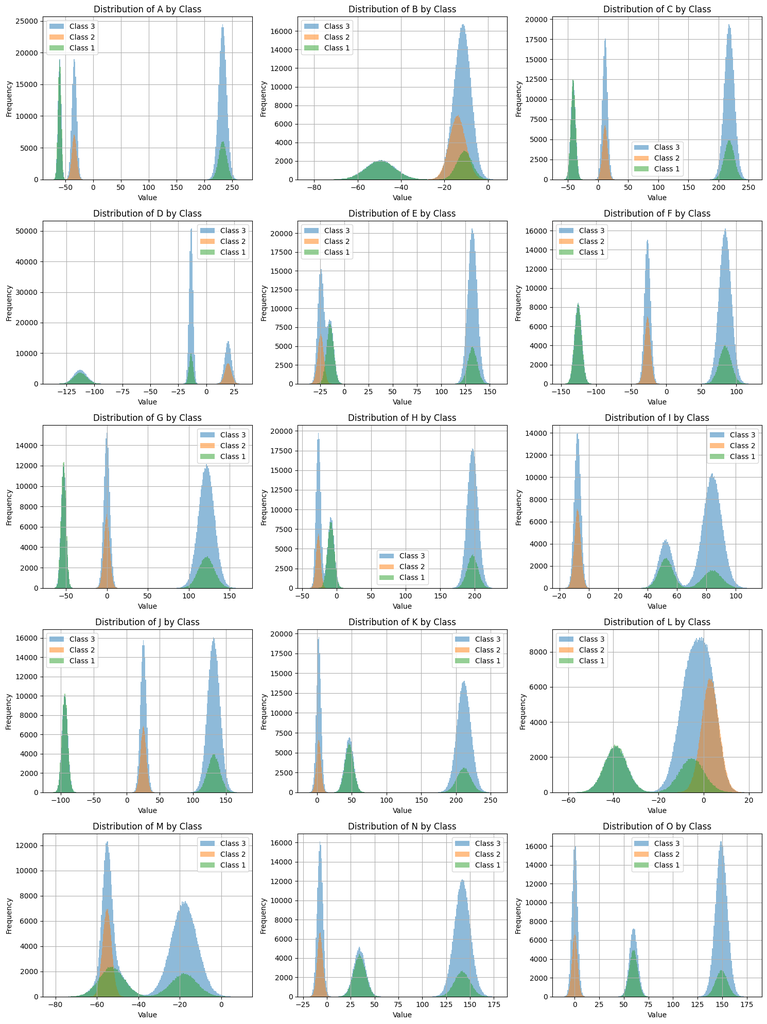

```python
fig, axes = plt.subplots(nrows=5, ncols=3, figsize=(15, 20))
axes = axes.flatten()

for idx, column in enumerate(df.drop(columns=['Class']).columns):
    ax = axes[idx]
    for label in df['Class'].unique():
        df[df['Class'] == label][column].hist(bins=250, alpha=0.5, label=f'Class {label}', ax=ax)

    ax.set_xlabel('Value')
    ax.set_ylabel('Frequency')
    ax.set_title(f'Distribution of {column} by Class')
    ax.legend()

for idx in range(len(df.drop(columns=['Class']).columns), len(axes)):
    fig.delaxes(axes[idx])

plt.tight_layout()
plt.show()
```

These graphs tell us a lot. Now we are aware that many of the variables' distributions are quite similar. With that being said, I think its best to universally scale the variables using one of the SciKit Learn Preprcoessing scalers.

After looking through the SKLearn Preprocessing documentation, we are debating between the StandardScaler and MinMaxScaler. We are most experienced with these two and believe either one will be sufficient in normalizing the data. In order to decide which one to use, we consulted stack overflow and the discussion provided a pretty clear explanation between the two. This made us rethink using a standard scaler, ultimately seeing the min-max scaler as the best option for our type of data. Standard scaler was mentioned as a useful tool for features that follow a normal distribution but most of our features are multimodal. Further, from the results of the agg call, we know the ranges of the variables which is needed when MinMax Scaling.

Using the MinMaxScaler, since all of the variables have negative values, we are going to scale the values into a range of [-1, 1].

```python
input_features = ['A', 'B', 'C', 'D', 'E', 'F', 'G', 'H', 'I', 'J', 'K', 'L', 'M', 'N', 'O']
scaler = MinMaxScaler(feature_range=(-1, 1))
scaler.fit(df[input_features])
df_scaled = pd.DataFrame(scaler.transform(df[input_features]), columns=input_features)
df_scaled['Class'] = df['Class']
df_scaled.agg(func=['mean', 'min', 'max', 'std', 'var'])
```

|  | A | B | C | D | E | F | G | H | I | J | K | L | M | N | O | Class |
| --- | --- | --- | --- | --- | --- | --- | --- | --- | --- | --- | --- | --- | --- | --- | --- | --- |
| mean | -0.275874 | 0.468685 | -0.168403 | 0.457300 | -0.309770 | 0.048995 | -0.154897 | -0.320390 | -0.209372 | 0.064933 | -0.317139 | 0.327709 | -0.147358 | -0.297580 | -0.249385 | 2.324106 |
| min | -1.000000 | -1.000000 | -1.000000 | -1.000000 | -1.000000 | -1.000000 | -1.000000 | -1.000000 | -1.000000 | -1.000000 | -1.000000 | -1.000000 | -1.000000 | -1.000000 | -1.000000 | 1.000000 |
| max | 1.000000 | 1.000000 | 1.000000 | 1.000000 | 1.000000 | 1.000000 | 1.000000 | 1.000000 | 1.000000 | 1.000000 | 1.000000 | 1.000000 | 1.000000 | 1.000000 | 1.000000 | 3.000000 |
| std | 0.756146 | 0.329903 | 0.666548 | 0.551026 | 0.742020 | 0.538403 | 0.572698 | 0.750918 | 0.651381 | 0.534473 | 0.692383 | 0.369453 | 0.390320 | 0.674475 | 0.690090 | 0.721146 |
| var | 0.571757 | 0.108836 | 0.444287 | 0.303629 | 0.550594 | 0.289878 | 0.327983 | 0.563877 | 0.424297 | 0.285662 | 0.479394 | 0.136496 | 0.152350 | 0.454917 | 0.476224 | 0.520052 |

You will see, that certain models used the RobustScaler from sklearn. For certain modelling the RobustScaler was perferred over the MinMaxScaler due to prevalence over outliers.

# Data Analysis

Then taking the techniques used from our homework (chapter 4, question 14) we explored the data graphically in order to investigate the association between class and the features to hopefully determine which features seem most likely to be useful in predicting class.

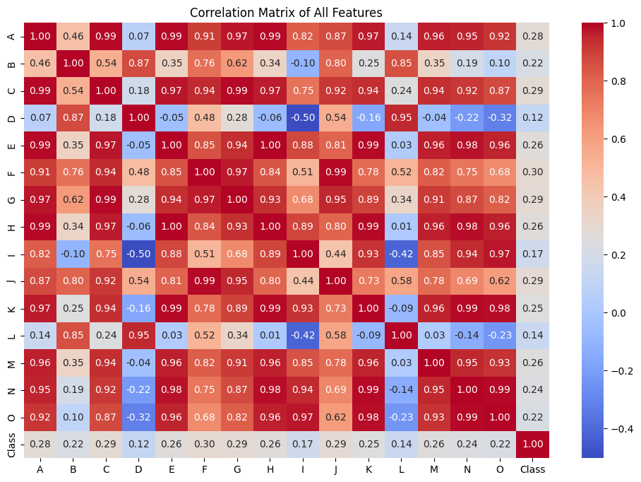

```python
# Correlation heatmap for feature selection
corr_matrix = df.corr()
class_corr = corr_matrix['Class'].drop('Class')
plt.figure(figsize=(12, 8))
sns.heatmap(corr_matrix, annot=True, fmt='.2f', cmap='coolwarm', cbar=True)
plt.title("Correlation Matrix of All Features")
plt.show()
```

### Explanation of the Heatmap and Top Features

The heatmap represents the pairwise Pearson correlation coefficients between all features and the target variable (Class).

Values range from -1 to 1:

```
1.0: Perfect positive correlation (as one feature increases, the other increases proportionally).
-1.0: Perfect negative correlation (as one feature increases, the other decreases proportionally).
0.0: No linear relationship between the variables.
```

The diagonal is always 1.0 because each feature is perfectly correlated with itself.

Now looking at all our correlations with Class, we see that it is all relatively low with a max of .30. This showed us our features have weak to moderate linear relationships. We were really hoping that we could single out features with higher correlation values so to provide us with more predictive power for the target variable but since no single feature strongly predicts the Class, we are forced to think harder and do more work with combining features or using non-linear methods to capture interactions. It was a good start to expirement with logistic regression for benchmarking. An ideal model would have to capture the more complex interactions and handle all this multicollinearity. Next steps may be to start testing with models like Random Forests or XGBoost for interpretability and non-linear learning.

```
Top features correlated with Class:
F    0.296131
J    0.293592
G    0.293204
C    0.287754
A    0.278329
Name: Class, dtype: float64
```

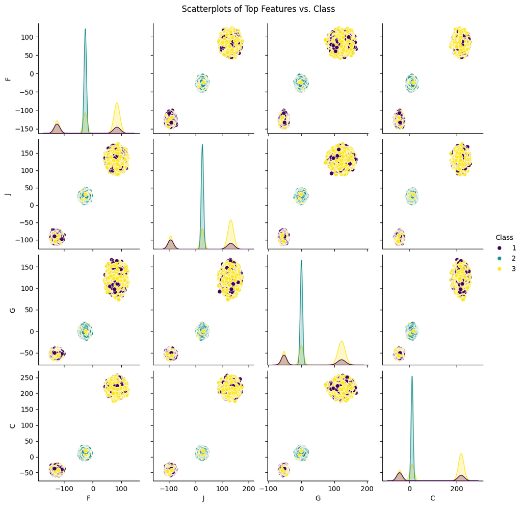

```python
# Display features most correlated with Class
print("\nTop features correlated with Class:")
print(class_corr.abs().sort_values(ascending=False).head(5))
top_features = class_corr.abs().sort_values(ascending=False).head(4).index.tolist()
sns.pairplot(df, vars=top_features, hue='Class', palette='viridis')
plt.suptitle("Scatterplots of Top Features vs. Class", y=1.02)
plt.show()
```

We also thought it would be useful to to apply principal component analysis to the 15 dimensions to determine the explained variance ratio, providing us insight towards which variables are responsible for the most variance and might lead us towards a greater understanding of the data.

While we would like to keep all of the variables when building models, it may be necessary to only model with the most principal components for memory sufficiency and time.

Further, gaining the 2 or 3 most principal components will allow us to visualize the class distributions in a vector space, getting a proper idea of what type of problem we are working with.

```python
df_pca = copy.copy(df_scaled)

pca = PCA()
principal_components = pca.fit_transform(df_pca.drop(columns=['Class']))
print("Explained Variance Ratio:", pca.explained_variance_ratio_)
```

```
Explained Variance Ratio: [8.29341619e-01 1.61369585e-01 2.01337891e-03 1.77809069e-03
 1.55128950e-03 7.43323482e-04 5.64748871e-04 4.93463128e-04
 4.07977239e-04 3.65198752e-04 3.28910777e-04 3.21062656e-04
 2.77215555e-04 2.56069283e-04 1.88067091e-04]
```

From this result, we observe the top two most principal components account for over 99% of the explained variance. By graphing the results of the principal component vectors and coloring the vectors by class, we can gain a good understanding of the distribution between Class 1, 2, and 3.

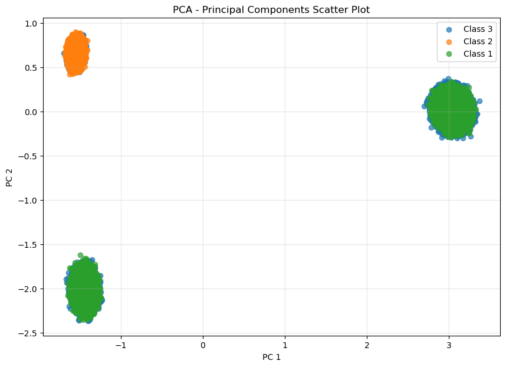

```python
pca = PCA(n_components=2)
principal_components = pca.fit_transform(df_pca.drop(columns=['Class']))

plot_pca = pd.DataFrame(data=principal_components, columns=['PC1', 'PC2'])
plot_pca['Class'] = df_pca['Class']

plt.figure(figsize=(10, 7))
for class_label in plot_pca['Class'].unique():
    subset = plot_pca[plot_pca['Class'] == class_label]
    plt.scatter(subset['PC1'], subset['PC2'], label=f'Class {class_label}', alpha=0.7)

plt.title("PCA - Principal Components Scatter Plot")
plt.xlabel("PC 1")
plt.ylabel("PC 2")
plt.legend()
plt.grid(alpha=0.3)
plt.show()
```

Looking at this graph, it is understandable why the informal logistic regression model built earlier performed so well after dropping Class 3. It appears there is very little mix, if any at all between Class 1 and 2 in the three clusters built by the data. Meanwhile, the Class 3 observations seem inseperable between Class 1 and 2.

With this type of result for the class distribution with the principal components, I chose to determine the cosine similarity between features and produce the amount of extremely similar observations that differ in Class label.

I did a bunch of research towards efficiently gaining the cosine similarity between the most observations but due to the nature of this type of algorithm, had to limit the size to 36,000 samples which is 3% of the total dataset, otherwise my program will fail due to memory overusage.

I used scipy.spatial.distance over the sklearn's cosine similarity function due to its ability to handle larger dataset sizes. I am not exactly sure about the process that utilizes RAM better but it works.

```python
df_tot = copy.copy(df_scaled)
X = df_tot.drop(columns=['Class'])
y = df_tot['Class']
X_train, X_test, y_train, y_test = train_test_split(X, y, test_size=0.97, random_state=3)
```

In the following code, I chose the cosine similarity threshold as 0.999, through multiple runs of the code and determined that threshold would produce the most desired result.

```python
X_train_np = X_train.to_numpy()

similarity_matrix = 1 - squareform(pdist(X_train_np, metric='cosine'))
threshold = 0.999
high_similarity_pairs = np.argwhere(similarity_matrix > threshold)

high_similarity_pairs = high_similarity_pairs[high_similarity_pairs[:, 0] < high_similarity_pairs[:, 1]]

similar = np.empty((0, 2))
for i in high_similarity_pairs:
    if (y_train.iloc[i[0]] != y_train.iloc[i[1]]):
        similar = np.vstack([similar, [i[0], i[1]]])
print(len(similar))
```

```
1146521
```

Okay, there are a lot of highly similar observations with different class labels. Let's print out two of these observations to ensure our algorithm is correct.

```python
class_a = y_train.iloc[int(similar[0, 0])]
class_b = y_train.iloc[int(similar[0, 1])]
observation_a = X_train.iloc[int(similar[0, 0])]
observation_b = X_train.iloc[int(similar[0, 1])]
print("Class: ", class_a, "\n", observation_a)
print("\nClass: ", class_b, "\n", observation_b)
observation_a = observation_a.to_numpy()
observation_b = observation_b.to_numpy()
print(np.dot(observation_a, observation_b) / (np.linalg.norm(observation_a) * np.linalg.norm(observation_b)))
```

```
Class:  3
 A   -0.810543
B    0.462527
C   -0.547673
D    0.885450
E   -0.861920
F   -0.110355
G   -0.424589
H   -0.851475
I   -0.869178
J   -0.071870
K   -0.893319
L    0.508495
M   -0.446079
N   -0.814815
O   -0.852556
Name: 1130342, dtype: float64

Class:  2
 A   -0.746047
B    0.509388
C   -0.553497
D    0.900772
E   -0.888752
F   -0.118118
G   -0.447083
H   -0.883334
I   -0.872514
J   -0.068696
K   -0.918434
L    0.495407
M   -0.415106
N   -0.779213
O   -0.867354
Name: 19673, dtype: float64
0.9991537292604398
```

It doesn't appear I have made any mistakes. These two observations appear highly similar but differ in classes. According to the principal component analysis plot shown above, the two observation seem to belong to the cluster in the top left. I should have known that cosine similarity would not be the best metric to gauge similarity due to the compactness of the three clusters.

With that being said, I am going to compute similar vectors using euclidean distance with the idea that magnitude is the key difference between observations belonging to a certain class.

```python
df_tot = copy.copy(df_scaled)
X = df_tot.drop(columns=['Class'])
y = df_tot['Class']
X_train, X_test, y_train, y_test = train_test_split(X, y, test_size=0.97, random_state=3)
```

Again, the training size is so small compared to the total dataset because of memory overusage problems for a training size any bigger.

```python
X_train_np = X_train.to_numpy()

distance_matrix = squareform(pdist(X_train_np, metric='euclidean'))
threshold = 0.05

high_similarity_pairs = np.argwhere(distance_matrix < threshold)
high_similarity_pairs = high_similarity_pairs[high_similarity_pairs[:, 0] < high_similarity_pairs[:, 1]]

similar = np.empty((0, 2))
for i in high_similarity_pairs:
    if (y_train.iloc[i[0]] != y_train.iloc[i[1]]):
        similar = np.vstack([similar, [i[0], i[1]]])
print(len(similar))
```

```
20
```

As we can see, amount of magnitude-similar vectors with differing classes is pretty frequent considering the low threshold of 0.05. With that being said, I am curious to see the type of production as a result of dropping these similar but different observations when building a model.

```python
drop_indices = similar.astype(int).ravel().tolist()
drop_indices = list(set(drop_indices))
print(len(drop_indices))
drop_indices = np.array(drop_indices)
drop_indices = X_train.index[drop_indices]
```

```
39
```

# Model Training

## Model Exploration

We started the modeling process by testing out some models we believe to work on the dataset. While we performed a bunch of data analysis, determining what type of models we should employ, I think it is important to consider the building singular models with default parameters.

```python
df_tot = copy.copy(df_scaled)
X = df_tot.drop(columns=['Class'])
y = df_tot['Class']
X_train, X_test, y_train, y_test = train_test_split(X, y, test_size=0.2, random_state=52)

logr = LogisticRegression()
logr.fit(X_train, y_train)
y_pred = logr.predict(X_test)

print("Accuracy: ", accuracy_score(y_test, y_pred))
print("Confusion Matrix: \n", confusion_matrix(y_test, y_pred))
```

```
Accuracy:  0.7246958333333333
Confusion Matrix:
 [[10102     0 25875]
 [    0 90131     0]
 [ 9979 30219 73694]]
```

```python
df_tot = copy.copy(df_scaled)
X = df_tot.drop(columns=['Class'])
y = df_tot['Class']
X_train, X_test, y_train, y_test = train_test_split(X, y, test_size=0.2, random_state=52)

rfc = RandomForestClassifier(n_estimators=100, random_state=11)
rfc.fit(X_train, y_train)
y_pred = rfc.predict(X_test)

print("Accuracy: ", accuracy_score(y_test, y_pred))
print("Confusion Matrix: \n", confusion_matrix(y_test, y_pred))
```

```
Accuracy:  0.7254583333333333
Confusion Matrix:
 [[11075     0 24902]
 [    0 90124     7]
 [10765 30216 72911]]
```

## Smote

```python
import logging
from imblearn.over_sampling import SMOTE
from sklearn.metrics import classification_report
import time

logging.basicConfig(level=logging.INFO, format='%(asctime)s - %(message)s')
start_time = time.time()
X_train = df_1_train.drop(columns=['Class', 'Class_i']).to_numpy()
X_test = df_1_test.drop(columns=['Class']).to_numpy()

y_train = df_1_train['Class'].to_numpy()
y_test = df_1_test['Class'].to_numpy()
logging.info(f"Original training data shape: {X_train.shape}, {y_train.shape}")
logging.info(f"Original test data shape: {X_test.shape}, {y_test.shape}")

# 1. Handle Class Imbalance with SMOTE
logging.info("Applying SMOTE to balance the dataset...")
smote_start = time.time()
smote = SMOTE(random_state=11)
X_train_resampled, y_train_resampled = smote.fit_resample(X_train, y_train)
logging.info(f"SMOTE completed in {time.time() - smote_start:.2f} seconds.")
logging.info(f"Resampled training data shape: {X_train_resampled.shape}, {y_train_resampled.shape}")

logging.info("Training Random Forest model with tuned hyperparameters...")
train_start = time.time()
rf_model = RandomForestClassifier(
    n_estimators=200,  # Increased number of trees
    max_depth=20,      # Limit tree depth for efficiency
    min_samples_split=5,  # Reduce overfitting
    max_features='sqrt',  # Use square root of features at each split
    random_state=11
)
rf_model.fit(X_train_resampled, y_train_resampled)
logging.info(f"Random Forest training completed in {time.time() - train_start:.2f} seconds.")

logging.info("Generating predictions on test data...")
predict_start = time.time()
y_pred = rf_model.predict(X_test)
logging.info(f"Predictions completed in {time.time() - predict_start:.2f} seconds.")

logging.info("Evaluating the model...")
accuracy = accuracy_score(y_test, y_pred)
conf_matrix = confusion_matrix(y_test, y_pred)
classification_report_str = classification_report(y_test, y_pred)

logging.info("Random Forest Accuracy: %.4f" % accuracy)
logging.info(f"Confusion Matrix:\n{conf_matrix}")
logging.info(f"Classification Report:\n{classification_report_str}")
logging.info(f"Total runtime: {time.time() - start_time:.2f} seconds.")
```

```
2024-11-30 17:36:28,554 - Original training data shape: (840000, 15), (840000,)
2024-11-30 17:36:28,555 - Original test data shape: (360000, 15), (360000,)
2024-11-30 17:36:28,555 - Applying SMOTE to balance the dataset...
2024-11-30 17:45:48,573 - SMOTE completed in 560.02 seconds.
2024-11-30 17:45:48,574 - Resampled training data shape: (1196460, 15), (1196460,)
2024-11-30 17:45:48,575 - Training Random Forest model with tuned hyperparameters...
2024-11-30 18:04:39,594 - Random Forest training completed in 1131.02 seconds.
2024-11-30 18:04:39,599 - Generating predictions on test data...
2024-11-30 18:04:45,603 - Predictions completed in 6.00 seconds.
2024-11-30 18:04:45,603 - Evaluating the model...
2024-11-30 18:04:45,790 - Random Forest Accuracy: 0.6868
2024-11-30 18:04:45,791 - Confusion Matrix:
[[ 34698      0  19840]
 [     0 134761      0]
 [ 47919  44989  77793]]
2024-11-30 18:04:45,791 - Classification Report:
              precision    recall  f1-score   support

           1       0.42      0.64      0.51     54538
           2       0.75      1.00      0.86    134761
           3       0.80      0.46      0.58    170701

    accuracy                           0.69    360000
   macro avg       0.66      0.70      0.65    360000
weighted avg       0.72      0.69      0.67    360000

2024-11-30 18:04:45,791 - Total runtime: 1697.37 seconds.
```

Training with balancing the classes using SMOTE actually decreased the accuracy so that suprised us even more. We want to try another approach though that involves our analysis from the heatmap. Our conclusion from earlier suggests multicollinearity within the features so we thought of using dimensionality reduction techniques like Principal Component Analysis (PCA) to mitigate that. An experiment with the a robust scaler was also used to handle outliers.

```python
from sklearn.preprocessing import RobustScaler
from sklearn.decomposition import PCA


logging.basicConfig(
    format='%(asctime)s - %(message)s',
    level=logging.INFO,
    datefmt='%Y-%m-%d %H:%M:%S'
)

logging.info("Starting Random Forest training with scaled and PCA-reduced data.")
start_time = time.time()
logging.info("Scaling features using RobustScaler...")
scaler = RobustScaler()
X_train_scaled = scaler.fit_transform(X_train)
X_test_scaled = scaler.transform(X_test)
logging.info("Feature scaling completed in %.2f seconds.", time.time() - start_time)

start_time = time.time()
logging.info("Applying PCA to reduce dimensionality...")
pca = PCA(n_components=10)  # Reduce to 10 components
X_train_pca = pca.fit_transform(X_train_scaled)
X_test_pca = pca.transform(X_test_scaled)
logging.info("PCA completed in %.2f seconds.", time.time() - start_time)
logging.info("Explained variance by PCA components: %s", pca.explained_variance_ratio_)

# Train Random Forest model
start_time = time.time()
logging.info("Training Random Forest with optimized hyperparameters...")
rf_model = RandomForestClassifier(
    n_estimators=300,
    max_depth=15,
    min_samples_leaf=5,
    class_weight='balanced_subsample',
    random_state=11
)
rf_model.fit(X_train_pca, y_train)
logging.info("Random Forest training completed in %.2f seconds.", time.time() - start_time)

start_time = time.time()
logging.info("Generating predictions on the test set...")
y_pred = rf_model.predict(X_test_pca)
logging.info("Predictions completed in %.2f seconds.", time.time() - start_time)
accuracy = accuracy_score(y_test, y_pred)
conf_matrix = confusion_matrix(y_test, y_pred)
classification_report_str = classification_report(y_test, y_pred)

logging.info("Random Forest Accuracy: %.4f", accuracy)
logging.info("Confusion Matrix:\n%s", conf_matrix)
logging.info("Classification Report:\n%s", classification_report_str)
logging.info("Random Forest process completed.")
```

```
2024-11-30 18:23:03,173 - Starting Random Forest training with scaled and PCA-reduced data.
2024-11-30 18:23:03,175 - Scaling features using RobustScaler...
2024-11-30 18:23:03,601 - Feature scaling completed in 0.43 seconds.
2024-11-30 18:23:03,602 - Applying PCA to reduce dimensionality...
2024-11-30 18:23:03,700 - PCA completed in 0.10 seconds.
2024-11-30 18:23:03,701 - Explained variance by PCA components: [7.08115957e-01 2.61231526e-01 2.04078567e-02 7.01992348e-03
 1.60303260e-03 3.67261985e-04 3.07880381e-04 2.59836053e-04
 2.01599467e-04 1.37861733e-04]
2024-11-30 18:23:03,702 - Training Random Forest with optimized hyperparameters...
2024-11-30 18:39:10,885 - Random Forest training completed in 967.18 seconds.
2024-11-30 18:39:10,887 - Generating predictions on the test set...
2024-11-30 18:39:16,140 - Predictions completed in 5.25 seconds.
2024-11-30 18:39:16,322 - Random Forest Accuracy: 0.7247
2024-11-30 18:39:16,322 - Confusion Matrix:
[[ 30310      0  24228]
 [     0 134761      0]
 [ 29892  44989  95820]]
2024-11-30 18:39:16,323 - Classification Report:
              precision    recall  f1-score   support

           1       0.50      0.56      0.53     54538
           2       0.75      1.00      0.86    134761
           3       0.80      0.56      0.66    170701

    accuracy                           0.72    360000
   macro avg       0.68      0.71      0.68    360000
weighted avg       0.74      0.72      0.71    360000

2024-11-30 18:39:16,323 - Random Forest process completed.
```